# Chapter 3

Megha Khanduri

2023-11-20

# Logistic Regression

Installing packages

```r
options(repos = list(CRAN="http://cran.rstudio.com/"))
install.packages("boot")
install.packages("readr")
install.packages("dplyr")
install.packages("tidyverse")
```

```r
install.packages("ggplot2")
install.packages("GGally")
install.packages("DT")
library(boot)
library(readr)
library(dplyr)
library(tidyverse)
library(ggplot2)
library(GGally)
library(DT)
```

Reading data

```r
alc <- read_csv("data/alc.csv")
```

```
## ──────────────────────────────────────────────────────── Delimiter: "," chr
## (17): school, sex, address, famsize, Pstatus, Mjob, Fjob, reason, guardi... dbl
## (19): ...1, ...2, age, Medu, Fedu, traveltime, studytime, famrel, freeti... lgl
## (1): high_use
```

## About the data and hypotheses

The data studies student performance in secondary education of two Portuguese schools. The data attributes include student grades, demographic, social and school related features, in the context of their performance in two distinct subjects, Mathematics and Portuguese language. In this chapter, we are interested in observing the relationship of alcohol consumption by students with some selected parameters. For this, we formulate the following hypotheses:

- Alcohol consumption varies significantly with **age (age)**, with older students consuming more alcohol than younger students
- Alcohol consumption varies significantly with **engagement in extra-curricular activities (activities)**, with students engaging in extracurricular activities consuming lesser alcohol.
- Alcohol consumption varies significantly with the **quality of family relationship (Famrel)**, with a better quality associated with lower alcohol consumption.
- Alcohol consumption varies significantly with the student’s **frequency of going out with friends (goout)**, higher frequency associated with higher alcohol consumption.

### Numerically and graphically testing hypotheses

We will use cross-tables to numerically explore the data to see if any of our hypotheses are correct.

Installing package

```r
install.packages("crosstable")
library(crosstable)
```

Numerical testing

```r
# age, famrel and goout are currently recognized as numerical variables, and that is messing up the output of this chunk. So, these variables have been converted to factors.
alc$age <- as.factor(alc$age)
alc$famrel <- as.factor(alc$famrel)
alc$goout <- as.factor(alc$goout)
t1 <- crosstable(alc,  c("age", "activities", "famrel", "goout"), by = high_use, total = c("row"), percent_pattern = "{n}({p_col}/{p_row})", percent_digits=0, funs = c(` ` = cross_summary))
as_flextable(t1)
```

| label | variable | high_use FALSE | high_use TRUE | Total |  |
| --- | --- | --- | --- | --- | --- |
| age | 15 | 63(24%/78%) | 18(16%/22%) |  | 81 (22%) |
|  | 16 | 74(29%/73%) | 28(25%/27%) | 102 (28%) |  |
|  | 17 | 62(24%/64%) | 35(32%/36%) | 97 (26%) |  |
|  | 18 | 52(20%/68%) | 25(23%/32%) | 77 (21%) |  |
|  | 19 | 7(3%/64%) | 4(4%/36%) | 11 (3%) |  |
|  | 20 | 1(0.4%/100%) | 0(0%/0%) | 1 (0.3%) |  |
|  | 22 | 0(0%/0%) | 1(1%/100%) | 1 (0.3%) |  |
| activities | no | 120(46%/67%) | 59(53%/33%) | 179 (48%) |  |
|  | yes | 139(54%/73%) | 52(47%/27%) | 191 (52%) |  |
| famrel | 1 | 6(2%/75%) | 2(2%/25%) | 8 (2%) |  |
|  | 2 | 9(3%/50%) | 9(8%/50%) | 18 (5%) |  |
|  | 3 | 39(15%/61%) | 25(23%/39%) | 64 (17%) |  |
|  | 4 | 128(49%/71%) | 52(47%/29%) | 180 (49%) |  |
|  | 5 | 77(30%/77%) | 23(21%/23%) | 100 (27%) |  |
| goout | 1 | 19(7%/86%) | 3(3%/14%) | 22 (6%) |  |
|  | 2 | 82(32%/85%) | 15(14%/15%) | 97 (26%) |  |
|  | 3 | 97(37%/81%) | 23(21%/19%) | 120 (32%) |  |
|  | 4 | 40(15%/51%) | 38(34%/49%) | 78 (21%) |  |
|  | 5 | 21(8%/40%) | 32(29%/60%) | 53 (14%) |  |

Graphical testing:

**1. Alcohol consumption vs Age**

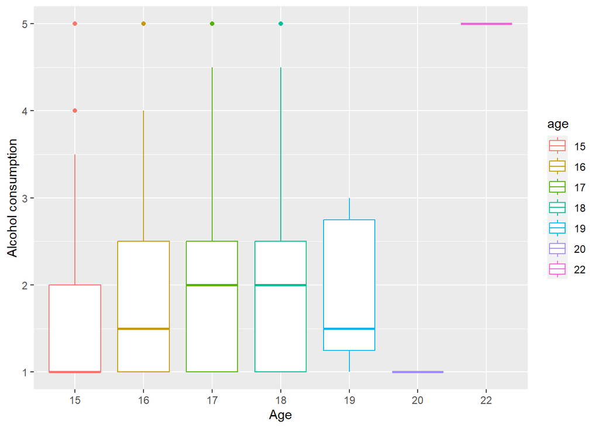

```r
ggplot(alc, aes(age, alc_use)) +geom_boxplot(aes(color = age)) +  xlab("Age") + ylab("Alcohol consumption")
```

Alcohol consumption appears to rise upto the age of 17-18, but there are no obvious trends beyond this point.

**2. Alcohol consumption vs Extracurricular Activities**

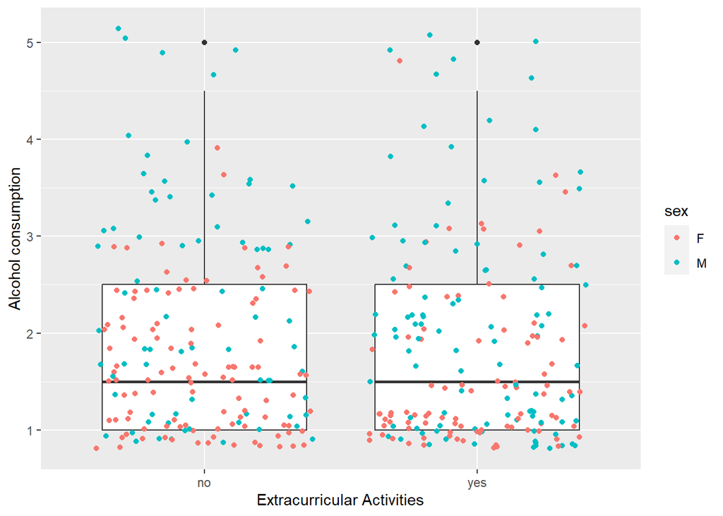

```r
ggplot(alc, aes(activities, alc_use)) +geom_boxplot() + geom_jitter(aes(color = sex)) + xlab("Extracurricular Activities") + ylab("Alcohol consumption")
```

Alcohol consumption appears to be more or less similar regardless of involvement in extra-curricular activities. Our hypothesis does not appear to hold true.

**3. Alcohol consumption vs Quality of family relationship**

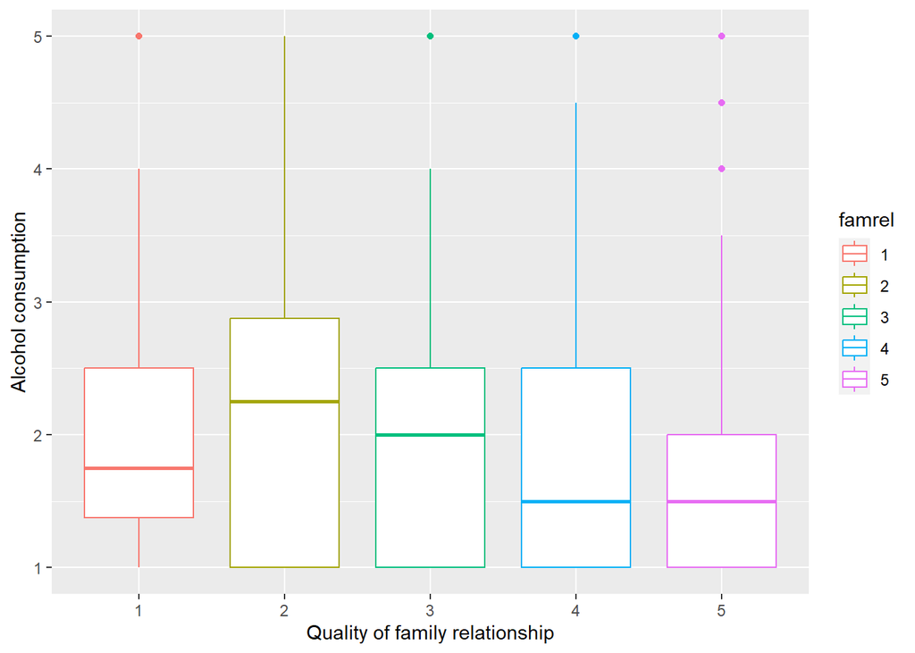

```r
ggplot(alc, aes(famrel, alc_use)) +geom_boxplot(aes(color = famrel)) + xlab("Quality of family relationship") + ylab("Alcohol consumption")
```

An imrproving relationship with one’s family appears to be associated with lower alcohol consumption in general.

**4. Alcohol consumption vs frequency of going out**

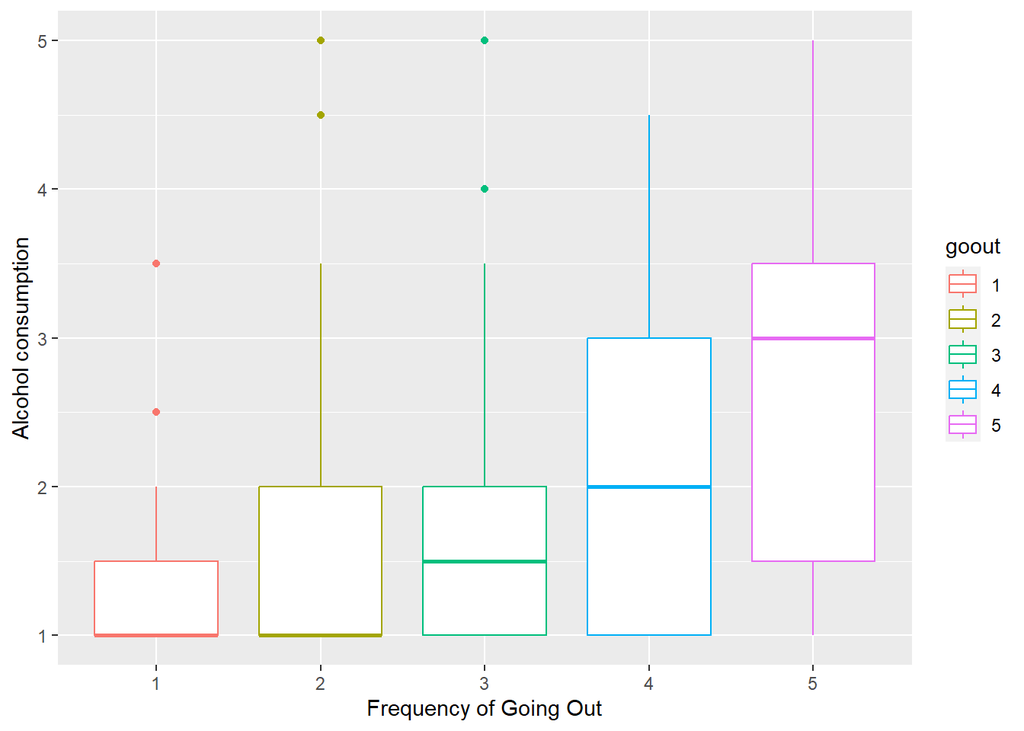

```r
ggplot(alc, aes(goout, alc_use)) +geom_boxplot(aes(color = goout)) + xlab("Frequency of Going Out") + ylab("Alcohol consumption")
```

The frequency of going out appears to have a direct relationship with alcohol consumption. Our hypothesis appears to be correct.

## Model:

**Generalized Linear Models** allow us to perform linear regressions for data that are not normally distributed. Since there are categorical variables, we cannot run linear regressions with normal distributions. We will therefore use the glm function with a **binomial distribution**.

```r
# Converting factors back to numeric for modeling
alc$age <- as.numeric(alc$age)
alc$famrel <- as.numeric(alc$famrel)
alc$goout <- as.numeric(alc$goout)
m <- glm(high_use ~ age + activities + famrel + goout, data = alc, family = "binomial")
summary(m)
```

```
##
## Call:
## glm(formula = high_use ~ age + activities + famrel + goout, family = "binomial",
##     data = alc)
##
## Deviance Residuals:
##     Min       1Q   Median       3Q      Max
## -1.5177  -0.8037  -0.5508   0.9968   2.4836
##
## Coefficients:
##               Estimate Std. Error z value Pr(>|z|)
## (Intercept)    -2.0469     0.6613  -3.095  0.00197 **
## age             0.1101     0.1087   1.013  0.31123
## activitiesyes  -0.3312     0.2491  -1.330  0.18360
## famrel         -0.3890     0.1358  -2.864  0.00419 **
## goout           0.7869     0.1208   6.514 7.33e-11 ***
## ---
## Signif. codes:  0 '***' 0.001 '**' 0.01 '*' 0.05 '.' 0.1 ' ' 1
##
## (Dispersion parameter for binomial family taken to be 1)
##
##     Null deviance: 452.04  on 369  degrees of freedom
## Residual deviance: 391.67  on 365  degrees of freedom
## AIC: 401.67
##
## Number of Fisher Scoring iterations: 4
```

```r
OR <- coef(m) %>% exp
CI <- confint(m)
cbind(OR, CI)
```

```
##                      OR      2.5 %     97.5 %
## (Intercept)   0.1291398 -3.3730441 -0.7716864
## age           1.1163679 -0.1029974  0.3243667
## activitiesyes 0.7180718 -0.8226507  0.1555969
## famrel        0.6777087 -0.6587038 -0.1241970
## goout         2.1965650  0.5565977  1.0312327
```

### Model Interpretation:

Of the four variables, only two have a **significant (p<0.01)** influence on whether or not the alcohol consumption by a student is high:

1. The quality of their relationship with their family, and
2. Their frequency of going out.

## Predictive Power:

```r
# Adding a column that displays the output for whether alcohol consumption is high or not, based on the model
## We first add a column that computes the probability for high alcohol consumption using our model

alc <- mutate(alc, probability = predict(m, type = "response"))

## If the probability is greater than 50% (or 0.5), the model will predict high alcohol consumption to be "True", and otherwise, "False". These outputs will be displayed in another column.  We call this column "prediction"

alc <- mutate(alc, prediction = probability > 0.5)




# Tabulating the target variable versus the predictions
table(high_use = alc$high_use, prediction = alc$prediction)
```

```
##         prediction
## high_use FALSE TRUE
##    FALSE   235   24
##    TRUE     71   40
```

[figure not shown]

```r
# Plotting the predictive power
g <- ggplot(alc, aes(x = "probability", y = "high use")) + geom_point()

g
```

From the table, it appears that the present model can fairly reliably predict when alcohol consumption is not high, but it can predict conditions of high alcohol consumption to be false as well. We will attempt to estimate the average number of wrongly classified students in the next steps:

```r
# define a loss function (mean prediction error)
loss_func <- function(class, prob) {
  n_wrong <- abs(class - prob) > 0.5
  mean(n_wrong)
}

loss_func(class = alc$high_use, prob = 0)
```

```
## [1] 0.3
```